# Dependency between the earths temperature and atmospheric C02-levels

## This file is an exploration and model building file

```python
import pandas as pd
import numpy as np
import matplotlib.pyplot as plt
from statsmodels.graphics.tsaplots import plot_acf, plot_pacf
import statsmodels.api as sm
from statsmodels.sandbox.regression.predstd import wls_prediction_std
```

## Get data to model the dependency between atmospheric C02 levels and temperatures on earth.

The data-source for the temperatures is the "Estimated Global Land-Surface TAVG based on the Complete Berkeley Dataset" provided by Berkley Earth: http://berkeleyearth.org/ . The data-source for the C02 levels is the Mauna Loa dataset obtained from the National Oceanic and Atmospheric Administration, US Department of Commerce. C02 data: ftp://ftp.cmdl.noaa.gov/ccg/co2/trends/co2_mm_mlo.txt , Temp data: http://berkeleyearth.lbl.gov/auto/Global/Complete_TAVG_complete.txt

```python
temp_header = [
    'Year',
    'Month',
    'Monthly Anomaly',
    'M.A. Unc.',
    'Annual Anomaly',
    'A.A. Unc.',
    'Five-year Anomaly',
    'F.y. Unc.',
    'Ten-year Anomaly',
    'T.y. Unc.',
    'Twenty-year Anomaly',
    'Tw.y. Unc.'
]
temp_df = pd.read_csv('http://berkeleyearth.lbl.gov/auto/Global/Complete_TAVG_complete.txt',
            delim_whitespace=True,
            comment='%',
            header=None,
            names=temp_header
            )
temp_df.head()
```

|  | Year | Month | Monthly Anomaly | M.A. Unc. | Annual Anomaly | A.A. Unc. | Five-year Anomaly | F.y. Unc. | Ten-year Anomaly | T.y. Unc. | Twenty-year Anomaly | Tw.y. Unc. |
| --- | --- | --- | --- | --- | --- | --- | --- | --- | --- | --- | --- | --- |
| 0 | 1750 | 1 | -0.000 | 3.803 | -0.709 | 2.397 | NaN | NaN | NaN | NaN | NaN | NaN |
| 1 | 1750 | 2 | -1.476 | 4.073 | -0.690 | 1.694 | NaN | NaN | NaN | NaN | NaN | NaN |
| 2 | 1750 | 3 | -0.464 | 5.561 | -0.705 | 1.622 | NaN | NaN | NaN | NaN | NaN | NaN |
| 3 | 1750 | 4 | 0.144 | 2.537 | -0.725 | 1.583 | NaN | NaN | NaN | NaN | NaN | NaN |
| 4 | 1750 | 5 | -1.227 | 2.812 | -1.060 | NaN | NaN | NaN | NaN | NaN | NaN | NaN |

Next the 'Year' and 'Month' colums are combined to a pd.Period called 'Time' so that it can eventually be used as the index for the dataframe.

```python
temp_df['Time'] = temp_df[['Year', 'Month']].apply(lambda row: pd.Period(year=row['Year'],month=row['Month'],freq='M') , axis=1)
temp_df.head()
```

|  | Year | Month | Monthly Anomaly | M.A. Unc. | Annual Anomaly | A.A. Unc. | Five-year Anomaly | F.y. Unc. | Ten-year Anomaly | T.y. Unc. | Twenty-year Anomaly | Tw.y. Unc. | Time |
| --- | --- | --- | --- | --- | --- | --- | --- | --- | --- | --- | --- | --- | --- |
| 0 | 1750 | 1 | -0.000 | 3.803 | -0.709 | 2.397 | NaN | NaN | NaN | NaN | NaN | NaN | 1750-01 |
| 1 | 1750 | 2 | -1.476 | 4.073 | -0.690 | 1.694 | NaN | NaN | NaN | NaN | NaN | NaN | 1750-02 |
| 2 | 1750 | 3 | -0.464 | 5.561 | -0.705 | 1.622 | NaN | NaN | NaN | NaN | NaN | NaN | 1750-03 |
| 3 | 1750 | 4 | 0.144 | 2.537 | -0.725 | 1.583 | NaN | NaN | NaN | NaN | NaN | NaN | 1750-04 |
| 4 | 1750 | 5 | -1.227 | 2.812 | -1.060 | NaN | NaN | NaN | NaN | NaN | NaN | NaN | 1750-05 |

Now the newly created column can be set as the index and redundant info dropped.

```python
temp_df = temp_df.set_index('Time')
temp_df = temp_df.drop(['Year',
                        'Month',
                        'Ten-year Anomaly',
                        'T.y. Unc.',
                        'Twenty-year Anomaly','Tw.y. Unc.'],
                         axis=1)
temp_df.head()
```

| Time | Monthly Anomaly | M.A. Unc. | Annual Anomaly | A.A. Unc. | Five-year Anomaly | F.y. Unc. |
| --- | --- | --- | --- | --- | --- | --- |
| 1750-01 | -0.000 | 3.803 | -0.709 | 2.397 | NaN | NaN |
| 1750-02 | -1.476 | 4.073 | -0.690 | 1.694 | NaN | NaN |
| 1750-03 | -0.464 | 5.561 | -0.705 | 1.622 | NaN | NaN |
| 1750-04 | 0.144 | 2.537 | -0.725 | 1.583 | NaN | NaN |
| 1750-05 | -1.227 | 2.812 | -1.060 | NaN | NaN | NaN |

Lets plot some timeseries to gain some understanding about the data

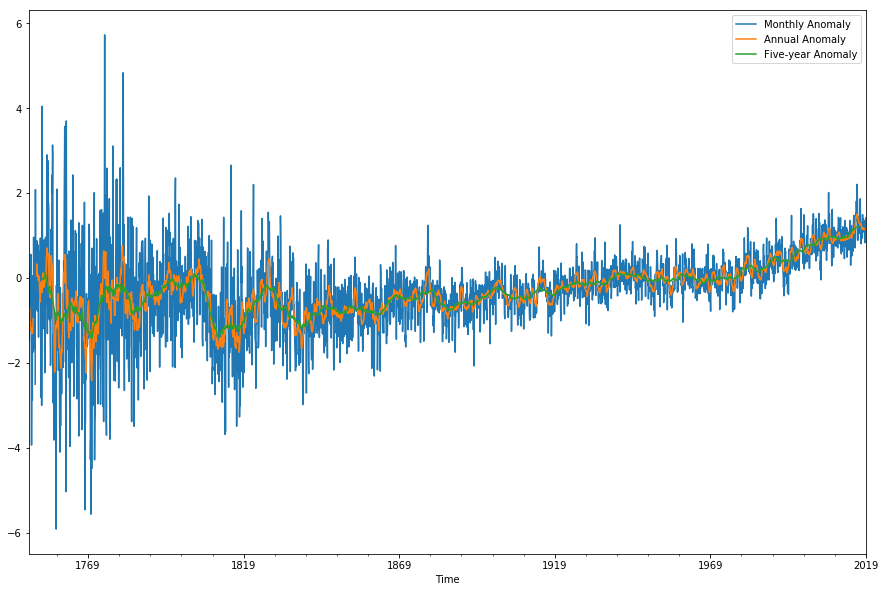

```python
temp_df.plot(y=['Monthly Anomaly','Annual Anomaly','Five-year Anomaly'],figsize=(15,10))
```

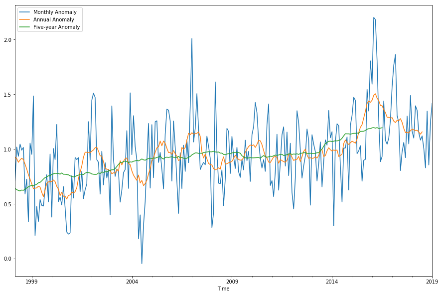

```python
temp_df['1998-3-1':].plot(y=['Monthly Anomaly','Annual Anomaly','Five-year Anomaly'],figsize=(15,10))
```

There seems to be alot of variance in the data. Especially in the Monthly Anomaly series, lets proceed with the more stable datasets; Annual Anomaly and Five-year Anomaly. Lets next explore possible seasonality and stationarity of the data set. Lets explore the autocorrelation and partial autocorrelation functions of the "Annual Anomality" and "Five-year Anomaly" to gain more insight into the data.

Annual Anomaly

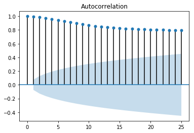

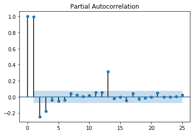

```python
plot_acf(temp_df['Annual Anomaly']['1960-3-1':].dropna(axis=0),lags=25);
plot_pacf(temp_df['Annual Anomaly']['1960-3-1':].dropna(axis=0),lags=25);
```

Five-year Anomaly

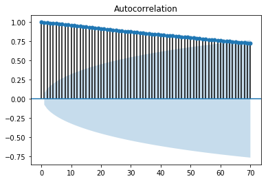

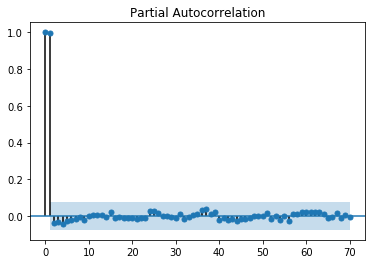

```python
plot_acf(temp_df['Five-year Anomaly']['1960-3-1':].dropna(axis=0),lags=70);
plot_pacf(temp_df['Five-year Anomaly']['1960-3-1':].dropna(axis=0),lags=70);
```

The correlation function show seasonality of one year for the annual series which it should at least according to common sense since each value is an "anomality" or difference in regards to averages estimated from Jan 1951-Dec 1980 monthly absolute temperatures. The values are a moving average centered around that month and referenced to the reference time frame. The five year series does not show significant seasonality which is good since seasonality introduces heteroscedasity which is to be avoided. The autocorrelation functions for both series shows that there seems to be a trend in the data so the series are non-stationary (in other words have a trend).

Lets bring in the data for C02 levels next. The data is reported as ppm C02 in dried air. In this series -99 is used to denote missing data in the average series.

```python
co2_header = [
    'Year',
    'Month',
    'decimal date',
    'average',
    'interpolated',
    'trend (season corr)',
    '#days'
]
co2_df = pd.read_csv('ftp://ftp.cmdl.noaa.gov/ccg/co2/trends/co2_mm_mlo.txt',
            delim_whitespace=True,
            comment='#',
            header=None,
            names=co2_header
            )
co2_df.head()
```

|  | Year | Month | decimal date | average | interpolated | trend (season corr) | #days |
| --- | --- | --- | --- | --- | --- | --- | --- |
| 0 | 1958 | 3 | 1958.208 | 315.71 | 315.71 | 314.62 | -1 |
| 1 | 1958 | 4 | 1958.292 | 317.45 | 317.45 | 315.29 | -1 |
| 2 | 1958 | 5 | 1958.375 | 317.50 | 317.50 | 314.71 | -1 |
| 3 | 1958 | 6 | 1958.458 | -99.99 | 317.10 | 314.85 | -1 |
| 4 | 1958 | 7 | 1958.542 | 315.86 | 315.86 | 314.98 | -1 |

Next the 'Year' and 'Month' colums are combined to a period so that it can eventually be used as the index

```python
co2_df['Time'] = co2_df[['Year', 'Month']].apply(lambda row: pd.Period(year=row['Year'],month=row['Month'],freq='M') , axis=1)
co2_df = co2_df.drop(['Year', 'Month', 'decimal date'],axis = 1)
co2_df = co2_df.set_index('Time')
co2_df.head()
```

| Time | average | interpolated | trend (season corr) | #days |
| --- | --- | --- | --- | --- |
| 1958-03 | 315.71 | 315.71 | 314.62 | -1 |
| 1958-04 | 317.45 | 317.45 | 315.29 | -1 |
| 1958-05 | 317.50 | 317.50 | 314.71 | -1 |
| 1958-06 | -99.99 | 317.10 | 314.85 | -1 |
| 1958-07 | 315.86 | 315.86 | 314.98 | -1 |

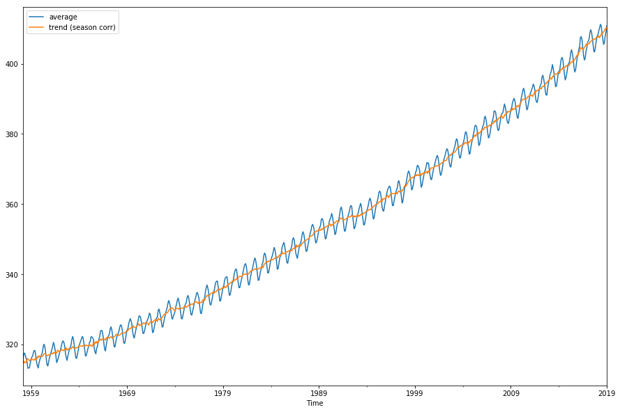

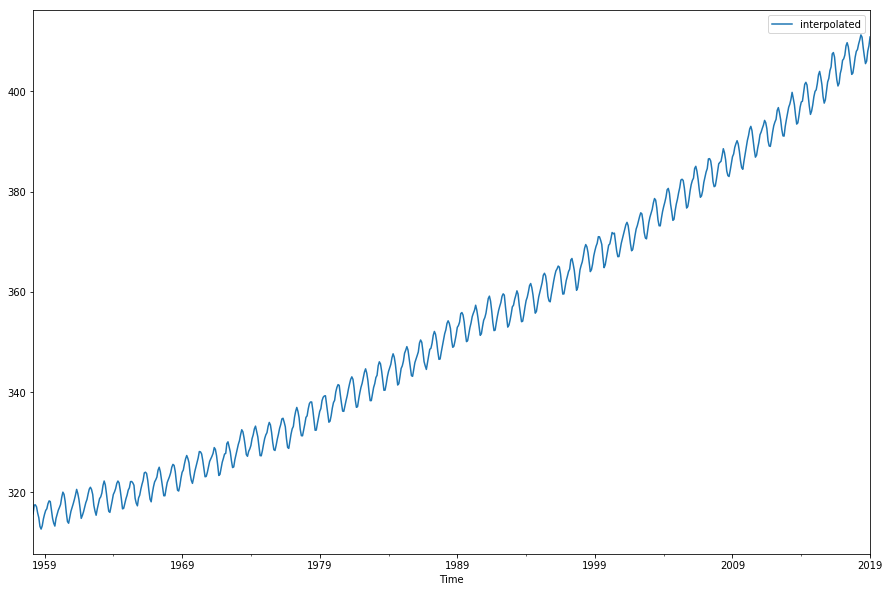

```python
# Lets again plot the series to gain a better understanding of it
co2_df[co2_df['average'] > -99].plot(y=['average','trend (season corr)'],figsize=(15,10))
co2_df.plot(y=['interpolated'],figsize=(15,10))
```

Since the data in the interpolated and average are so close there seems to be no benefit to using the raw average data since it may contain missing data that has to be dealt with. The CO2 data shows clear seasonality so to avoid heteroscedasticity we will use the seasonaly corrected trend data series. The seasonality will be confirmed by an acf-plot:

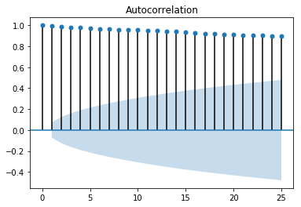

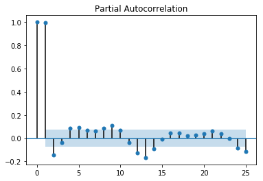

```python
plot_acf(co2_df['interpolated'],lags=25);
plot_pacf(co2_df['interpolated'],lags=25);
```

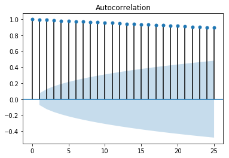

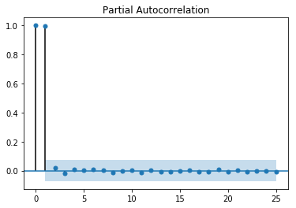

```python
plot_acf(co2_df['trend (season corr)'],lags=25);
plot_pacf(co2_df['trend (season corr)'],lags=25);
```

After examining plots, acf and pacf plots for both series we see that both the CO2 and the temperature data display an increasing trend (backed by acf plots). Additionally the CO2 shows yearly seasonality in the average and interpolated data columns. Based on this the model will be built using the "'Five-year Anomaly'" series and the "trend (season corr)" series where the seasonality of the year has been cancelled. Next the datasets are combined to one dataframe.

```python
model_df = pd.merge(co2_df, temp_df, left_index=True, right_index=True)
model_df = model_df.drop(['average',
                          'Annual Anomaly',
                          'interpolated',
                          '#days',
                          'M.A. Unc.',
                          'Monthly Anomaly',
                          'A.A. Unc.',
                          'F.y. Unc.'],
                          axis = 1)
model_df = model_df.dropna(axis=0)
# a const column of 1 has to be added for statsmodels ordinary least squares
# to estimate the intercept
model_df['const'] = 1
model_df.head()
```

| Time | trend (season corr) | Five-year Anomaly | const |
| --- | --- | --- | --- |
| 1958-03 | 314.62 | -0.053 | 1 |
| 1958-04 | 315.29 | -0.057 | 1 |
| 1958-05 | 314.71 | -0.059 | 1 |
| 1958-06 | 314.85 | -0.043 | 1 |
| 1958-07 | 314.98 | -0.036 | 1 |

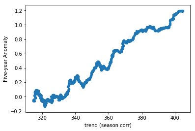

```python
model_df.plot.scatter('trend (season corr)', 'Five-year Anomaly')
```

The relationship seems to be linear so linear regression will be used to find a model.

```python
regr =  sm.OLS(endog=model_df['Five-year Anomaly'], exog=model_df[['const', 'trend (season corr)']], missing='drop')
results = regr.fit()
print(results.summary())
```

```
                            OLS Regression Results
==============================================================================
Dep. Variable:      Five-year Anomaly   R-squared:                       0.955
Model:                            OLS   Adj. R-squared:                  0.955
Method:                 Least Squares   F-statistic:                 1.498e+04
Date:                Fri, 01 Mar 2019   Prob (F-statistic):               0.00
Time:                        06:17:19   Log-Likelihood:                 746.41
No. Observations:                 701   AIC:                            -1489.
Df Residuals:                     699   BIC:                            -1480.
Df Model:                           1
Covariance Type:            nonrobust
=======================================================================================
                          coef    std err          t      P>|t|      [0.025      0.975]
---------------------------------------------------------------------------------------
const                  -4.8578      0.043   -112.754      0.000      -4.942      -4.773
trend (season corr)     0.0150      0.000    122.401      0.000       0.015       0.015
==============================================================================
Omnibus:                       35.221   Durbin-Watson:                   0.011
Prob(Omnibus):                  0.000   Jarque-Bera (JB):               24.878
Skew:                           0.351   Prob(JB):                     3.96e-06
Kurtosis:                       2.400   Cond. No.                     4.81e+03
==============================================================================

Warnings:
[1] Standard Errors assume that the covariance matrix of the errors is correctly specified.
[2] The condition number is large, 4.81e+03. This might indicate that there are
strong multicollinearity or other numerical problems.
```

The regression analysis shows that the R-squared value is 0.955. This means that 95% of the variance in five-year average temperature anomalities is explained by the parts per million C02 amount of dried air. In other words there is a strong correlation between atmospheric C02 levels and earth temperature. This is further confirmed by the F-test for linear regression which claims that there is a chance of less than 0.005 that these result were obtained by chance. the estimated coefficient is 0.0150, which means that the temperature will increase by 0.015 for each additional ppm of C02 in the atmosphere. Next the lets inspect the results with a plot.

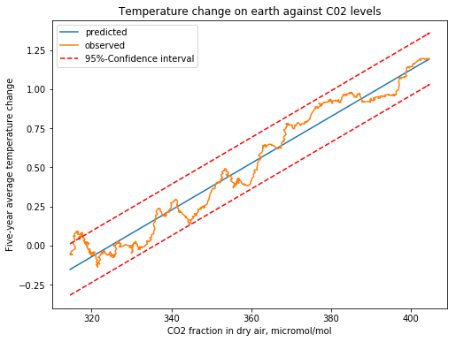

```python
plt.figure(figsize=(8,6))
prstd, iv_l, iv_u = wls_prediction_std(results)
# Plot predicted values
plt.plot(model_df['trend (season corr)'], results.predict(), label='predicted')
# Plot observed values
plt.plot(model_df['trend (season corr)'], model_df['Five-year Anomaly'], label='observed')
#plot confidence intervals
plt.plot(model_df['trend (season corr)'], iv_l,'r--', label='95%-Confidence interval')
plt.plot(model_df['trend (season corr)'], iv_u,'r--')

plt.legend()
plt.title('Temperature change on earth against C02 levels')
plt.xlabel('CO2 fraction in dry air, micromol/mol')
plt.ylabel('Five-year average temperature change')
plt.show()
```

## Predictions about the future

Lets assume that the C02 levels continue to rise at the same pace for the next 20 years. What would the temperature on earth be then according to the model. Lets first examine what the rise in C02 levels have been on average during the last 5 years.

```python
co2_diff_df = co2_df['2014-1-1':]['trend (season corr)']
co2_diff_df = co2_diff_df.diff().dropna(axis=0)
print('Average increase of C02 per month during the last 5 years:')
print(co2_diff_df.mean())
co2_avg_change = co2_diff_df.mean()
```

```
Average increase of C02 per month during the last 5 years:
0.21583333333333315
```

Lets next extrapolate the increase in C02 for the next 20 years. make new df

```python
future_df = co2_df.iloc[-20*12:].copy()
# make new index for 20 years in to the future
future_df['new index'] = co2_df.iloc[-20*12:].index.shift(20*12)
# use the last C02 measurement for starting value for extrapolation
future_df['trend (season corr)'] = co2_df['trend (season corr)'].iloc[-1]
future_df = future_df.assign(trend=np.arange(start= 1,stop=20*12+1))
#Extrapolate
future_df['trend'] = future_df['trend'] * co2_avg_change
future_df['extrapolated trend'] = future_df['trend (season corr)'] +future_df['trend']

# clean up
future_df.index = future_df['new index']
future_df = future_df.drop(['average','interpolated','#days','new index', 'trend (season corr)', 'trend'],axis = 1)
future_df.index.rename('Time', inplace= True)
future_df.tail()
```

| Time | extrapolated trend |
| --- | --- |
| 2038-09 | 461.436667 |
| 2038-10 | 461.652500 |
| 2038-11 | 461.868333 |
| 2038-12 | 462.084167 |
| 2039-01 | 462.300000 |

Plot of the extrapolated CO2 values

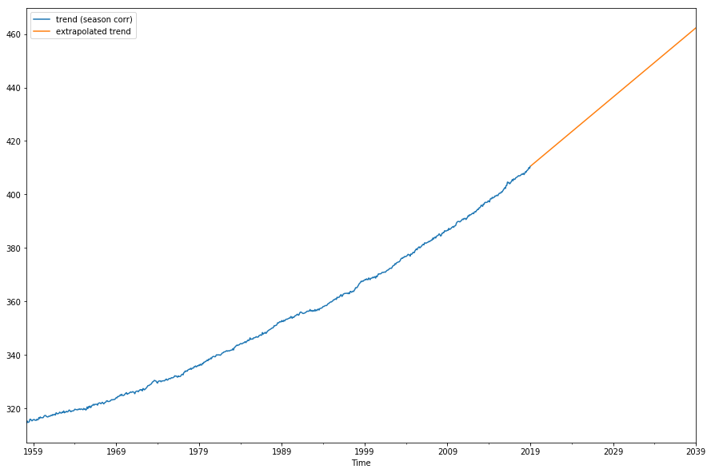

```python
co2_df.append(future_df).plot(y=['trend (season corr)','extrapolated trend'],figsize=(15,10))
```

Next the model is used to estimate how the temperature would change assuming CO2 levels would continue to rise as extrapolated.

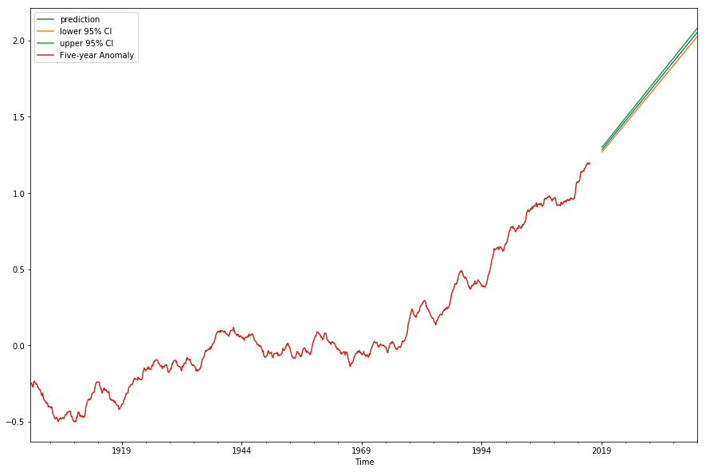

```python
prediction = results.get_prediction(exog=sm.add_constant(future_df))
prediction_df = prediction.summary_frame().rename(
                                                  {'mean': 'prediction', 'mean_ci_lower': 'lower 95% CI', 'mean_ci_upper': 'upper 95% CI'},
                                                  axis='columns'
                                                 )
temp_df['1900-1-1':].append(prediction_df).plot(y=['prediction','lower 95% CI','upper 95% CI','Five-year Anomaly'],figsize=(15,10))
```